# Importing Data & Tidy Data

Activity 07

Author

Solution

## Overview

The focus of Activity 07 will be on how to import and tidy data. This activity also offers additional review, in practice you should almost always be using data wrangling in conjunction with visualizations to explain your data.

## Needed Packages

The following loads the packages that are needed for this activity. We assume that you have installed the packages. Also note that we have suppressed the `message`s so the compiled html is less cluttered.

**Make sure to add the necessary packages!!**

```r
# LOAD THE NECESSARY PACKAGES
library(tidyverse)
library(skimr)
```

## Task 1

### Import data

We will be exploring the `mm_data.csv` dataset stored in your `data` subdirectory.

The M&M data was collected by students in past introductory courses and workshops. The dataset contains the count for each color (blue, orange, green, yellow, brown, and red) for 303 1.69 oz bags of milk chocolate M&M’s.

```r
#import data
mm_data <- read_csv("data/mm_data.csv")
```

Begin by inspecting `mm_data`. Hopefully it is clear that this is not a tidy dataset. Explain why it is not tidy.

## Task 2

Tidy `mm_data`. That is, use `pivot_longer()` to tidy up the dataset and store it in `mm_data_tidy`.

```r
# tidy and store m&m data
mm_data_tidy <- mm_data |>
  pivot_longer(col = -bag,
               names_to = "color",
               values_to = "n")
# print mm_data_tidy
mm_data_tidy
```

```
# A tibble: 1,818 × 3
     bag color      n
   <dbl> <chr>  <dbl>
 1     1 blue       6
 2     1 orange    18
 3     1 green     12
 4     1 yellow     6
 5     1 brown      7
 6     1 red        7
 7     2 blue      15
 8     2 orange    11
 9     2 green      9
10     2 yellow     1
# ℹ 1,808 more rows
```

## Tidy 3

Use the `skim()` function to determine the number of variables, observations, identify any missingness issues, and check for any potentially weird values that could cause issues in the analysis.

```r
# skim dataset
skim(mm_data_tidy)
```

Data summary

| Name | mm_data_tidy |
| --- | --- |
| Number of rows | 1818 |
| Number of columns | 3 |
| _______________________ |  |
| Column type frequency: |  |
| character | 1 |
| numeric | 2 |
| ________________________ |  |
| Group variables | None |

**Variable type: character**

| skim_variable | n_missing | complete_rate | min | max | empty | n_unique | whitespace |
| --- | --- | --- | --- | --- | --- | --- | --- |
| color | 0 | 1 | 3 | 6 | 0 | 6 | 0 |

**Variable type: numeric**

| skim_variable | n_missing | complete_rate | mean | sd | p0 | p25 | p50 | p75 | p100 | hist |
| --- | --- | --- | --- | --- | --- | --- | --- | --- | --- | --- |
| bag | 0 | 1 | 152.00 | 87.49 | 1 | 76 | 152 | 228 | 303 | ▇▇▇▇▇ |
| n | 0 | 1 | 9.37 | 4.04 | 0 | 6 | 9 | 12 | 28 | ▂▇▃▁▁ |

## Task 4

Create a plot that shows the distribution of `count` by `color`.

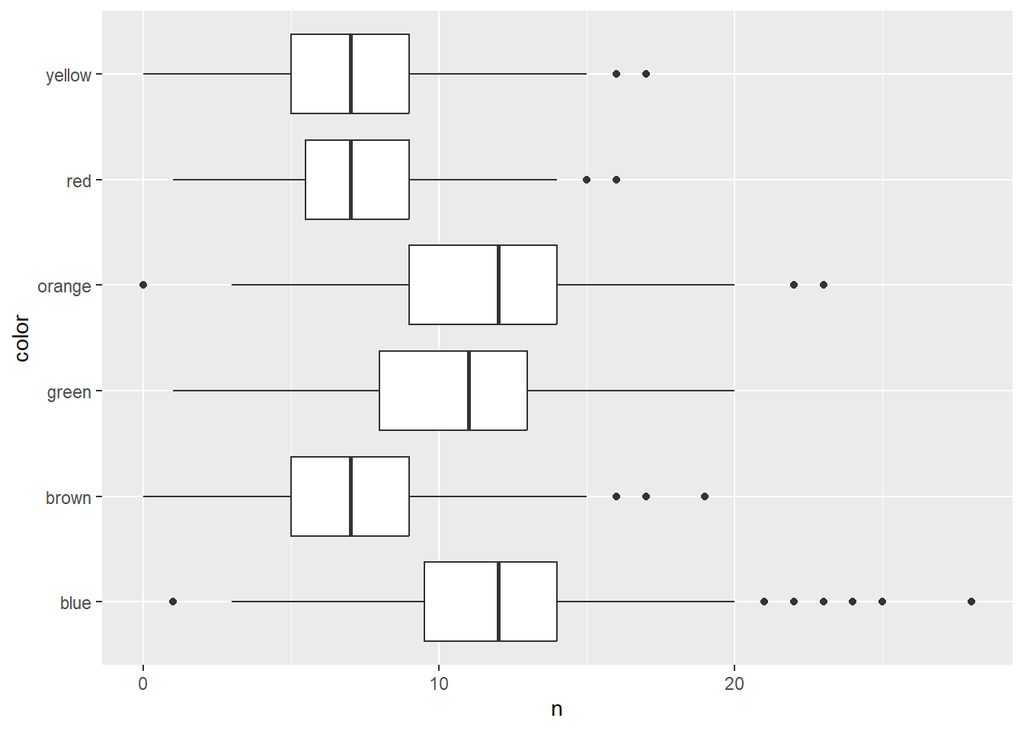

```r
# plot of mm color
ggplot(mm_data_tidy, aes(x = n, y = color)) +
  geom_boxplot()
```

```r
# summary statistics for the number of each color in a bag
mm_data_tidy |>
  group_by(color) |>
  summarize(mean = mean(n),
            sd = sd(n),
            median = median(n),
            iqr = IQR(n),
            min = min(n),
            max = max(n),
            count = n())
```

```
# A tibble: 6 × 8
  color   mean    sd median   iqr   min   max count
  <chr>  <dbl> <dbl>  <dbl> <dbl> <dbl> <dbl> <int>
1 blue   12.2   4.02     12   4.5     1    28   303
2 brown   7.22  3.00      7   4       0    19   303
3 green  10.6   3.63     11   5       1    20   303
4 orange 11.8   3.51     12   5       0    23   303
5 red     7.37  2.75      7   3.5     1    16   303
6 yellow  7.00  3.17      7   4       0    17   303
```

In a few sentences, describe what the summary statistics tell you about the distributions of the number of colors per bag of milk chocolate M&M’s that are in the sample. Should be able to describe what a “typical” bag of M&M’s from the sample would have in terms of colors.

## Optional Challenges

**Do not have to complete.**

### Challenge 1

The second argument you give it is where to save it and its file name, `"data/mm_tidy.csv"` which is telling R to write it out to the `data/` subdirectory and name the file `"mm_tidy.csv"`.

Try it out and verify that it is now in your `data/` subdirectoy.

```r
# write data out
```